# tidytuesday_13

Gustavo

2022-12-27

# Collegiate Sports in the US

The data this week comes from Equity in Athletics Data Analysis, hattip to Data is Plural, and more can be found on the [TidyTuesday website](https://github.com/rfordatascience/tidytuesday/blob/master/data/2022/2022-03-29/readme.md).

We’re gonna begin by loading the data, since it is already clean. The main goal here is to do some exploratory analysis.

```r
library(tidyverse)
sports_raw <- read_csv('https://raw.githubusercontent.com/rfordatascience/tidytuesday/master/data/2022/2022-03-29/sports.csv')
```

First, we can combine some of the sports to make our life easier in the future.

Before sparsing the data:

```r
unique(sports_raw$sports)
```

```
##  [1] "Baseball"                   "Basketball"
##  [3] "All Track Combined"         "Football"
##  [5] "Golf"                       "Soccer"
##  [7] "Softball"                   "Tennis"
##  [9] "Volleyball"                 "Bowling"
## [11] "Rifle"                      "Beach Volleyball"
## [13] "Ice Hockey"                 "Lacrosse"
## [15] "Gymnastics"                 "Rowing"
## [17] "Swimming and Diving"        "Track and Field, X-Country"
## [19] "Equestrian"                 "Track and Field, Indoor"
## [21] "Track and Field, Outdoor"   "Wrestling"
## [23] "Other Sports"               "Rodeo"
## [25] "Skiing"                     "Swimming"
## [27] "Water Polo"                 "Archery"
## [29] "Field Hockey"               "Fencing"
## [31] "Sailing"                    "Badminton"
## [33] "Squash"                     "Diving"
## [35] "Synchronized Swimming"      "Table Tennis"
## [37] "Weight Lifting"             "Team Handball"
```

After sparsing the data:

```r
sports_parsed <- sports_raw %>%
  mutate(sports = case_when(
    str_detect(sports, "Swimming") ~ "Swimming and Diving",
    str_detect(sports, "Swimming") ~ "Swimming and Diving",
    str_detect(sports, "Track") ~ "Track",
    TRUE ~ sports))

unique(sports_parsed$sports)
```

```
##  [1] "Baseball"            "Basketball"          "Track"
##  [4] "Football"            "Golf"                "Soccer"
##  [7] "Softball"            "Tennis"              "Volleyball"
## [10] "Bowling"             "Rifle"               "Beach Volleyball"
## [13] "Ice Hockey"          "Lacrosse"            "Gymnastics"
## [16] "Rowing"              "Swimming and Diving" "Equestrian"
## [19] "Wrestling"           "Other Sports"        "Rodeo"
## [22] "Skiing"              "Water Polo"          "Archery"
## [25] "Field Hockey"        "Fencing"             "Sailing"
## [28] "Badminton"           "Squash"              "Diving"
## [31] "Table Tennis"        "Weight Lifting"      "Team Handball"
```

The sports contemplated in this dataset as its popularity (number of rows) can be found below. Since it is a USA data, makes sense that basketball is the main sport contemplated in this dataset, followed by volleyball, soccer and baseball.

```r
sports_raw %>%
  group_by(sports) %>%
  summarise(n = n()) %>%
  arrange(desc(n))
```

```
## # A tibble: 38 × 2
##    sports                         n
##    <chr>                      <int>
##  1 Basketball                 10000
##  2 Volleyball                  9122
##  3 Soccer                      8647
##  4 Baseball                    8644
##  5 Softball                    8560
##  6 Golf                        7060
##  7 Tennis                      6418
##  8 Football                    5310
##  9 Track and Field, X-Country  4923
## 10 All Track Combined          4870
## # … with 28 more rows
```

We’re gonna use `bind_rows()` function to create a new dataset with only some variables of interest.

```r
sports <- bind_rows(
  sports_parsed %>%
    select(year, institution_name, sports,
           participants = partic_men,
           revenue = rev_men,
           expenditure = exp_men) %>%
    mutate(gender = "men"),
  sports_parsed %>%
    select(year, institution_name, sports,
           participants = partic_women,
           revenue = rev_women,
           expenditure = exp_women) %>%
    mutate(gender = "women")) %>%
  na.omit()

head(sports)
```

```
## # A tibble: 6 × 7
##    year institution_name         sports     participants revenue expend…¹ gender
##   <dbl> <chr>                    <chr>             <dbl>   <dbl>    <dbl> <chr>
## 1  2015 Alabama A & M University Baseball             31  345592   397818 men
## 2  2015 Alabama A & M University Basketball           19 1211095   817868 men
## 3  2015 Alabama A & M University Track                61  183333   246949 men
## 4  2015 Alabama A & M University Football             99 2808949  3059353 men
## 5  2015 Alabama A & M University Golf                  9   78270    83913 men
## 6  2015 Alabama A & M University Tennis                7   78274    99612 men
## # … with abbreviated variable name ¹expenditure
```

Let’s do a beautiful plot:

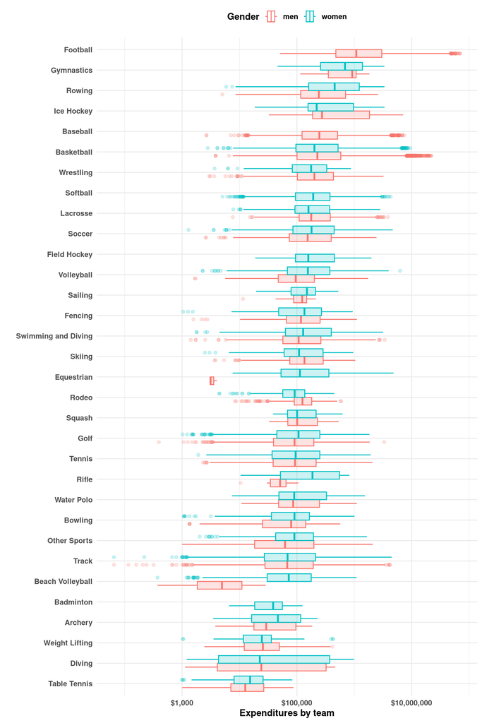

```r
sports %>%
  mutate(sports = fct_reorder(sports, expenditure)) %>%
  ggplot(aes(x = expenditure, y = sports, color = gender, fill = gender))+
  geom_boxplot(position = position_dodge(preserve = "single"), alpha = 0.2)+
  scale_x_log10(labels = scales::dollar)+
  theme_minimal()+
  theme(legend.position = "top", text = element_text(face = "bold"))+
  guides(fill = "none")+
  labs(x = "Expenditures by team", y = "", color = "Gender", fill = NULL)
```

Big gap difference specially in football and basketball (also in beach volley) when we account for gender. Now, following the screencast, we’re going to do a multiple linear regression accounting for sports and ignoring sports for predicting expenditures by team.

# Linear models

Julia suggests we use a more ‘R base’ approach in order to build the models. So we go on:

```r
ignore_sport <- lm(expenditure ~ gender + participants, data = sports)
account_for_sport <- lm(expenditure ~ gender + participants + sports, data = sports)
```

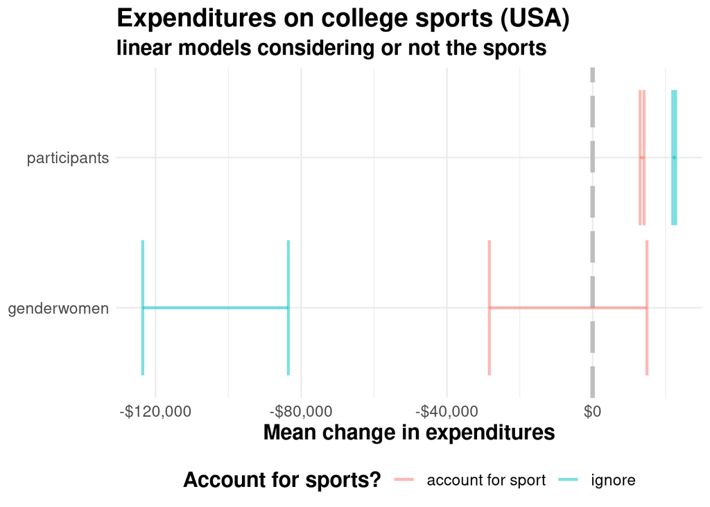

```r
library(broom)

bind_rows(
  tidy(ignore_sport) %>% mutate(sports = "ignore"),
  tidy(account_for_sport) %>%  mutate(sports = "account for sport")
) %>%
  filter(!str_detect(term, "sports"), term != "(Intercept)") %>%
  ggplot(aes(estimate, term, color = sports))+
  geom_vline(xintercept = 0.0, colour = "gray", lty = 5, size = 1.5)+
  geom_errorbar(aes(xmin = estimate - 1.96*std.error, xmax = estimate + 1.96*std.error), size = 1, alpha = 0.5)+
  scale_x_continuous(labels = scales::dollar)+
  theme_minimal()+
  theme(legend.position = "bottom", text = element_text(size = 14), title = element_text(size = 15, face = "bold"))+
  labs(y = NULL, color = "Account for sports?", x = "Mean change in expenditures", title = "Expenditures on college sports (USA)", subtitle = "linear models considering or not the sports")
```

# Bootstrap

We can use another statistical approach for estimating the intervals of the models using bootstrapping of the sample and estimating. One can use the `reg_intervals()` function part of the `rsample` library. Since this is a stochastic process, we need to set a seed using `set.seed()` for the pseudo-random bootstrapping of samples.

```r
library(rsample)

doParallel::registerDoParallel()

set.seed(123)
ignore_intervals <-
  reg_intervals(expenditure ~ gender + participants, data = sports, times = 500)

account_for_sport_intervals <-
  reg_intervals(expenditure ~ gender + participants + sports, data = sports, times = 500)
```

How does the output look? What are the coefficients when we consider the sports?

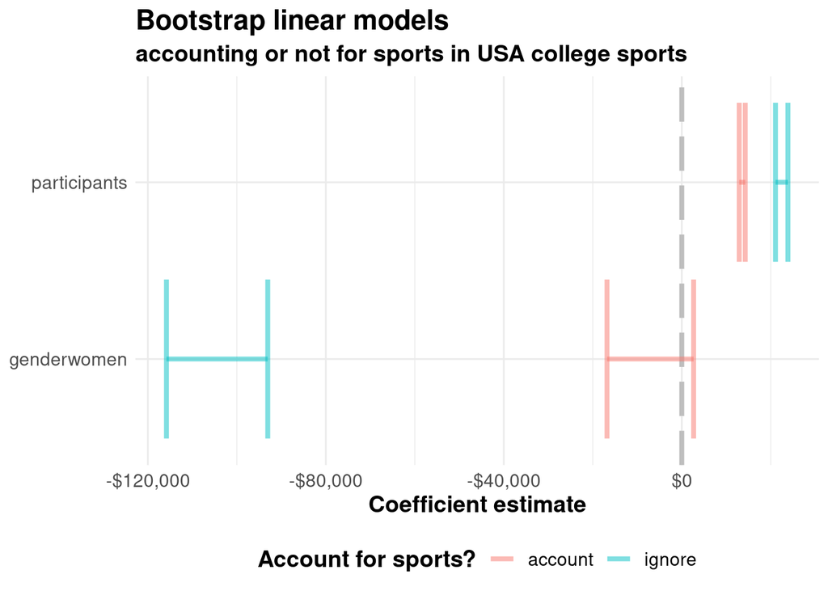

```r
bind_rows(
  ignore_intervals %>%
    mutate(sports = "ignore"),
  account_for_sport_intervals %>%
    filter(!str_detect(term,"sports")) %>%
    mutate(sports = "account")
) %>%
  ggplot(aes(.estimate, term, color = sports))+
  geom_vline(xintercept = 0, color = "gray", lty = 5, size = 1.4)+
  geom_errorbar(aes(xmin = .lower, xmax = .upper), size = 1.4, alpha = 0.5)+
  scale_x_continuous(labels = scales::dollar)+
  theme_minimal()+
  theme(text = element_text(size = 14),
        title = element_text(face = "bold"),
        legend.position = "bottom")+
  labs(y = NULL, x = "Coefficient estimate",
       title = "Bootstrap linear models ",
       subtitle = "accounting or not for sports in USA college sports",
       color = "Account for sports?")
```

Well, unsurprisingly we got the same results but using bootstrapping of linear model coefficients. We can see that when we account for sports, the estimate of expenditures mean change considering only gender, i.e the coefficient **“genderwomen”** in this model passes through zero, that is, is not significant. But when we ignore the sports, there is a big difference.